# STAT 631 ROS Chapter3: Probability Basics

## Discrete Random Variables

### Binomial Random Variables

The Binomial model is helpful when we want to model the number of successes when we draw a random sample from a really big population (by big I mean big enough where it is really unlikely someone would be sampled twice) or when we have a random process with independent trials and two possible outcomes, such as coin flipping or in a manufacturing process where each product is either “in spec” or “out of spec”. Probabilities were being calculated with this distribution as far back as the early 18th century. It is attributed to Bernoulli. Interestingly the normal distribution was discovered by Abraham de Moivre later in the 18th century as he was needing to calculate probabilities from the Binomial for gambling problems. The binomial model is NOT always the right model to use as is discussed in the book.

The Poisson distribution is another famous distribution that is frequently used in practice. It is usually used in scenarios where we are counting the occurrences of certain events in an interval of time or space. Or it is used when as an approximation to the Binomial when n is large and p is very small. The PMF of the Poisson is given by:

$f(k;\lambda )=\Pr(X=k)={\frac {\lambda ^{k}e^{-\lambda }}{k!}}$

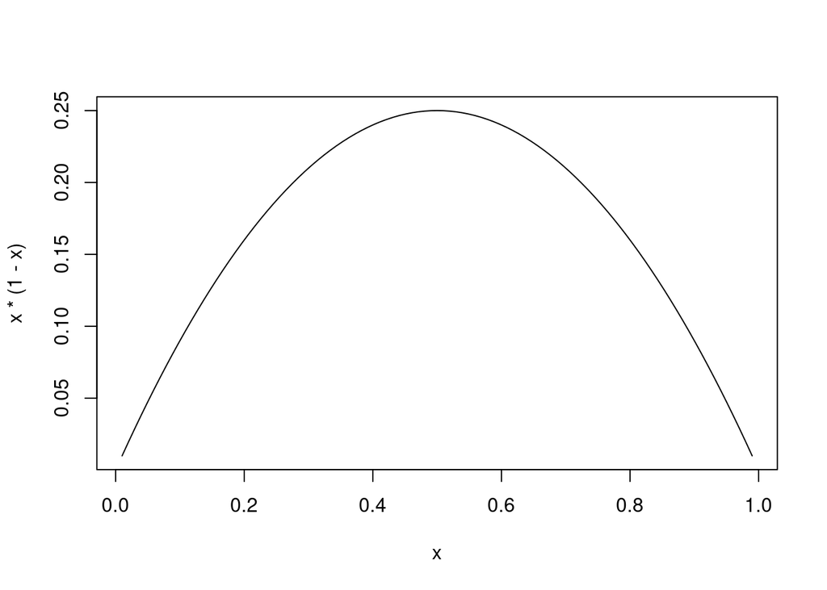

```r
curve(x*(1-x), from=.01, to = .99, main="")
```

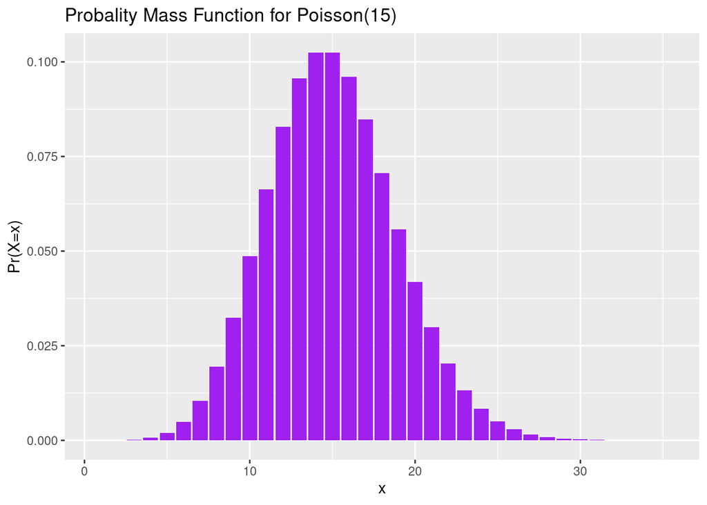

```r
poissonpmf <-
  tibble (x=1:35, prob=dpois(x,15))

ggplot(data=poissonpmf, mapping=
         aes(x=x,y=prob))+
  geom_col(fill='purple') +
  ggtitle("Probality Mass Function for Poisson(15)") +   xlab("x") + ylab("Pr(X=x)")
```

Suppose that we are counting the number of customers who visit a certain store from 1pm to 2pm. Based on data from previous days, we know that on average $\lambda=15$ customers visit the store. Of course, there will be more customers some days and fewer on others. Here, we may model the random variable X showing the number customers as a Poisson random variable with parameter $\lambda=15$

Suppose, the number of emails that I get in a weekday can be modeled by a Poisson distribution with an average of 0.2 emails per minute.